# World Bank Indicator Visualizations

Mohit Jain

19/02/2020

## CO2 Emissions by Country

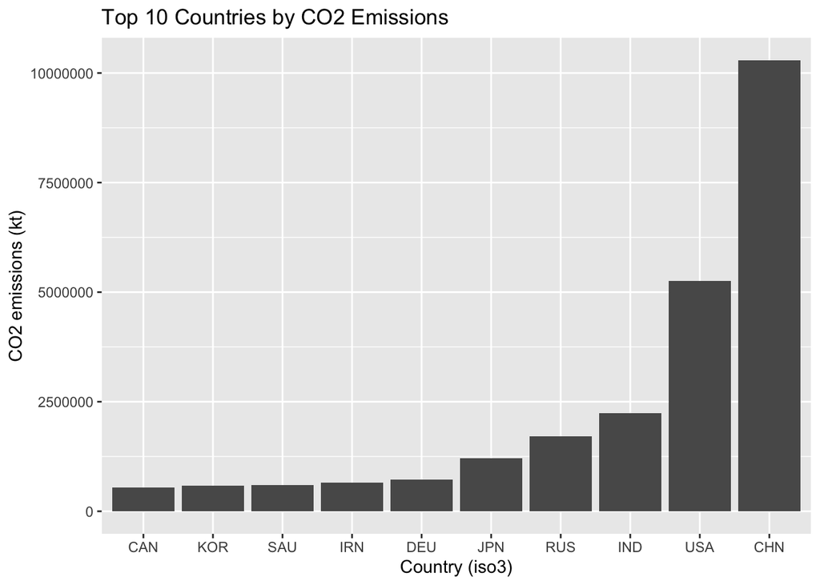

China is releasing more CO2 than any other country, maybe because China produces a lot of products made in factories and the fact it is very populated.

## US Income Equality over Time

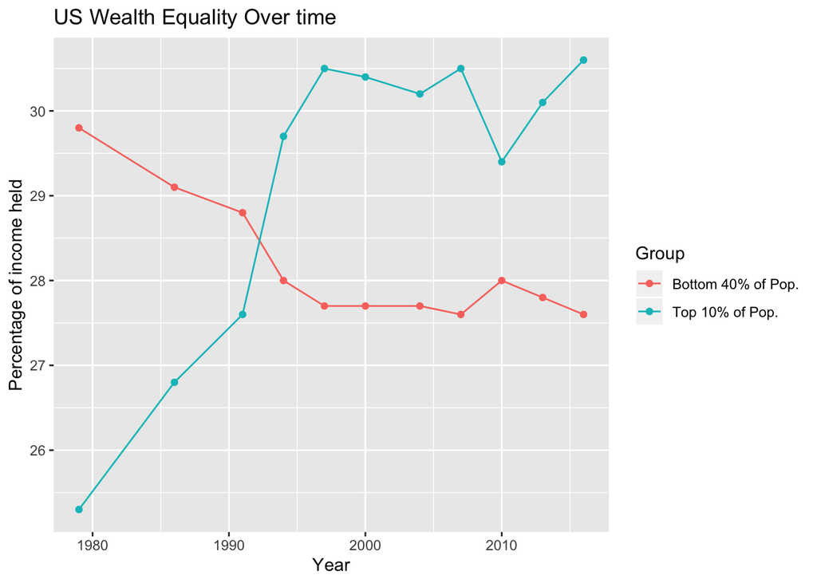

The difference between US income equality has grown over time, the income held by top 10% has grown over time while the bottom 40% has seen a decrease.

## Health Expenditures by Country

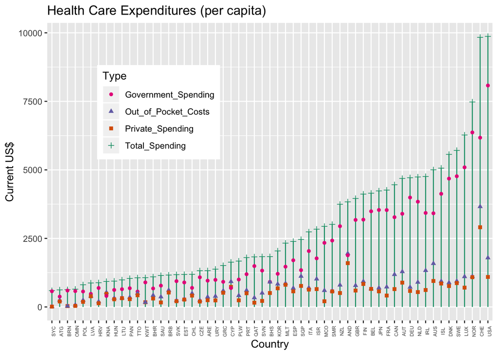

US goverement spends the most on health care than any other government.

## Map: Changes in Forestation around the World

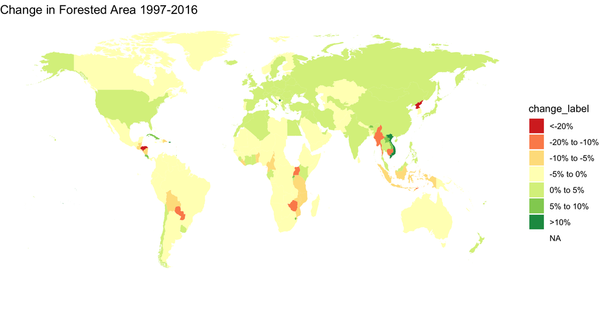

## Mortality rate among infants and Total Health Expenditure

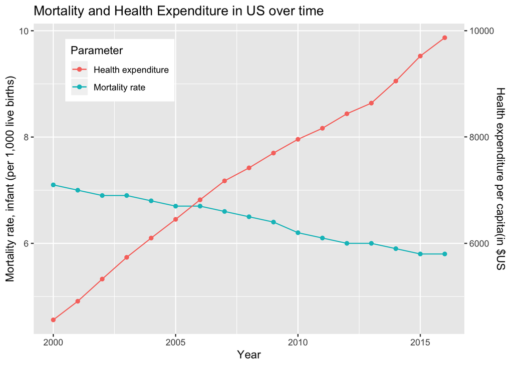

The visualization attempts to show there is correlation between health expenditure and mortaliy rate among infants

It is clear from the graph as health expenditure increased the mortality rate among infants decreased. Although the rate of increase in health expenditure is much higher than the rate of decrease in mortality rate.

The line graph shows the clear rate of increase and decrease among the parameter. The point graph helps the reader to read the values for a given year.

People can see that there is relationship with infant mortality and health expenditure. Second y-axis was added as the scale of the values did not match. The labeling and legend is appropriate and easily understandable.